# A network approach to ResPOnsE COVID-19 dataset

Arturo Bertero

# Introduction

This paper summarizes the analyses I performed on ResPOnsE COVID-19 dataset, wave 1. The focus is on results, hence the theoretical part is missing and will be integrated in the future. The broad aim of this paper is to compare the two most important methodologies for network estimation: *mgm* and CAN.

The Mixed Graphical Model (*mgm*) from Haslbeck & Waldorp (2020) allows to insert continuous and categorical variables in the model. CAN model is better able to generate predictive hypotheses regarding network’s dynamics, although being limited to dummy variables only. In order to understand the validity of these methods when applied to empirical case studies, this paper examine how network methodologies can help us to understand the network of attitudes regarding compliance toward preventive behaviors against COVID-19. While doing so, a Structural Equation Model will be used as a *benchmark* to inspect whether these methodologies are capable of grasping complex interaction between an heterogeneous set of variables.

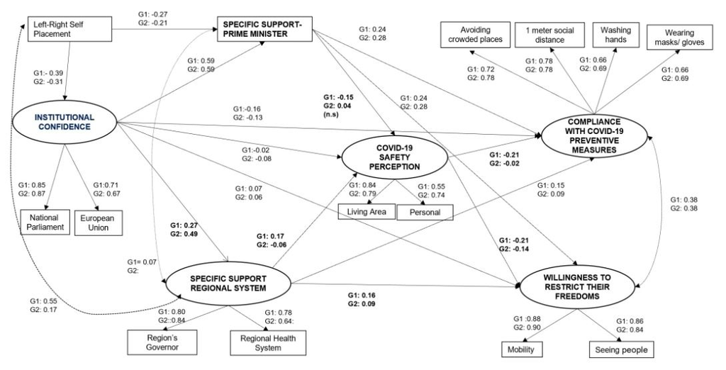

SEM by Guglielmi et al.(2020)

My idea is to use the SEM in Figure 1 above as the the “true model” against which CAN and *mgm* will be compared. Network methodologies and SEM present important differences. SEM is theory driven, and arrows are modeled on the basis of sound theories. In psychological networks ties are undirected, so that causal inferences are always bidirectional. These methods are more exploratory in nature; a tie is drawn when two variables (nodes) are statistically dependent, even after controlling for every other node in the network. Hence, these methods can help us to discover new and unforeseeable patterns among survery’s items.

This brief paper is structured in two sections. First, I will apply CAN and *mgm* to the same variables and data composing the SEM in Figure 1. Here I will examine the differences between different network estimation procedures, and those between them and SEM. Second, I will enlarge the scope of the analysis, by widening the list of nodes included in the compliance’s networks.